# Pertemuan 7

Natasha Muti Hafiza

2023-10-16

## Packages

```r
library(ggplot2)
library(tsibble)
library(tseries)
library(MASS)
library(forecast)
library(TSA)
library(TTR)
library(aTSA)
library(graphics)
```

```r
dataa <- rio::import("https://raw.githubusercontent.com/natashamuti/mpdw-ako/main/pertemuan%201/data.csv")
str(dataa)
```

```
## 'data.frame':    249 obs. of  2 variables:
##  $ Date: chr  "30/01/2021" "29/01/2021" "28/01/2021" "27/01/2021" ...
##  $ High: num  34933 38532 33784 32557 32922 ...
```

```r
data <- dataa$High
data
```

```
##   [1] 34933.00 38531.90 33783.98 32557.29 32921.88 34875.00 33071.00 33456.00
##   [9] 33826.53 35600.00 36415.31 37850.00 37469.83 36852.50 37950.00 39747.76
##  [17] 40100.00 37850.00 36628.00 38264.74 41350.00 41380.00 41950.00 40365.00
##  [25] 36939.21 34360.00 33600.00 34778.11 33300.00 29600.00 29300.00 28996.00
##  [33] 27410.00 27500.00 28422.00 26867.03 24789.86 23794.43 24100.00 23837.10
##  [41] 24102.77 24295.00 24171.47 23285.18 23800.00 21560.00 19570.00 19349.00
##  [49] 19411.00 18948.66 18292.73 18557.32 18639.57 19294.84 19420.91 19420.00
##  [57] 19177.00 19527.00 19598.00 19342.00 19888.00 19863.16 18360.05 17880.49
##  [65] 17457.62 18915.03 19484.21 19418.97 18766.00 18750.00 18965.90 18815.22
##  [73] 18179.80 18476.93 17858.82 16880.00 16180.00 16326.99 16480.00 16340.70
##  [81] 15965.00 15460.00 15840.00 15650.00 15753.52 15960.00 15750.00 14259.00
##  [89] 14066.11 13830.00 13895.00 14100.00 13669.98 13642.91 13859.48 13789.29
##  [97] 13238.81 13350.00 13166.73 13027.69 13185.00 13217.68 12038.38 11823.99
## [105] 11505.00 11402.42 11541.15 11617.34 11547.98 11557.00 11720.01 11445.00
## [113] 11491.00 11104.64 10950.00 10681.87 10800.00 10798.00 10696.87 10603.56
```

[output cut: 17 more lines]

```r
dc.train <- data[1:200]
dc.test <- data[201:249]
```

### Eksplorasi Data

Sebelum masuk dalam tahap pemodelan, dilakukan eksplorasi data dengan plot deret waktu untuk melihat pola data.

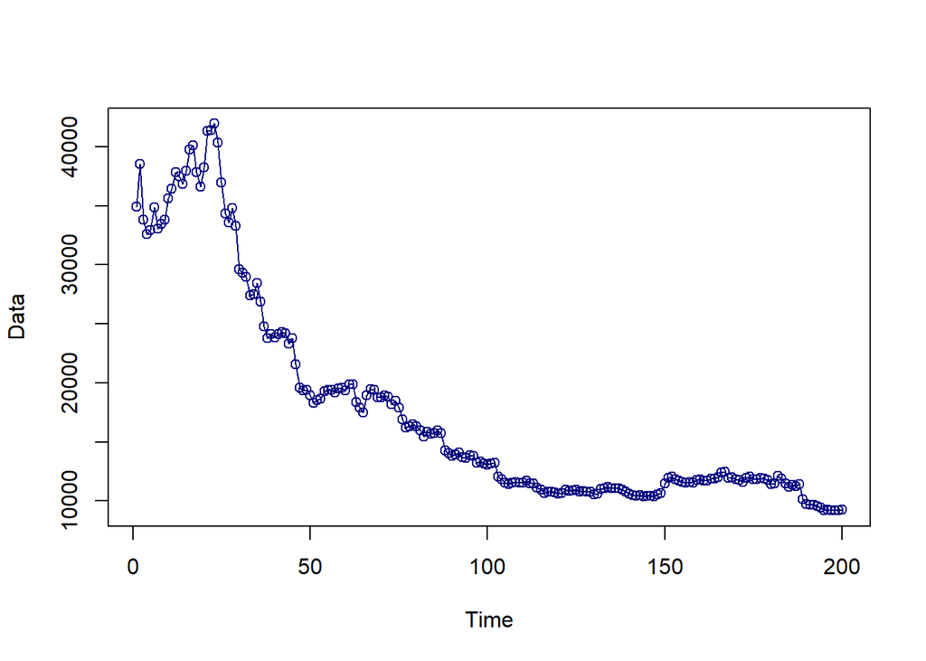

```r
#--PLOT TIME SERIES--#
plot(dc.train,
     col = "navyblue",
     lwd = 1,
     type = "o",
     xlab = "Time",
     ylab = "Data")
```

Berdasarkan plot data deret waktu di atas, terlihat data cenderung tidak stasioner dalam rataan dan ragam. Data tidak stasioner dalam rataan karena terdapat tren dan dikatakan tidak stasioner dalam ragam karena memiliki lebar pita yang cenderung berbeda. Selain dengan plot data deret waktu, akan dilakukan pengecekan stasioneritas data dengan plot ACF dan uji ADF.

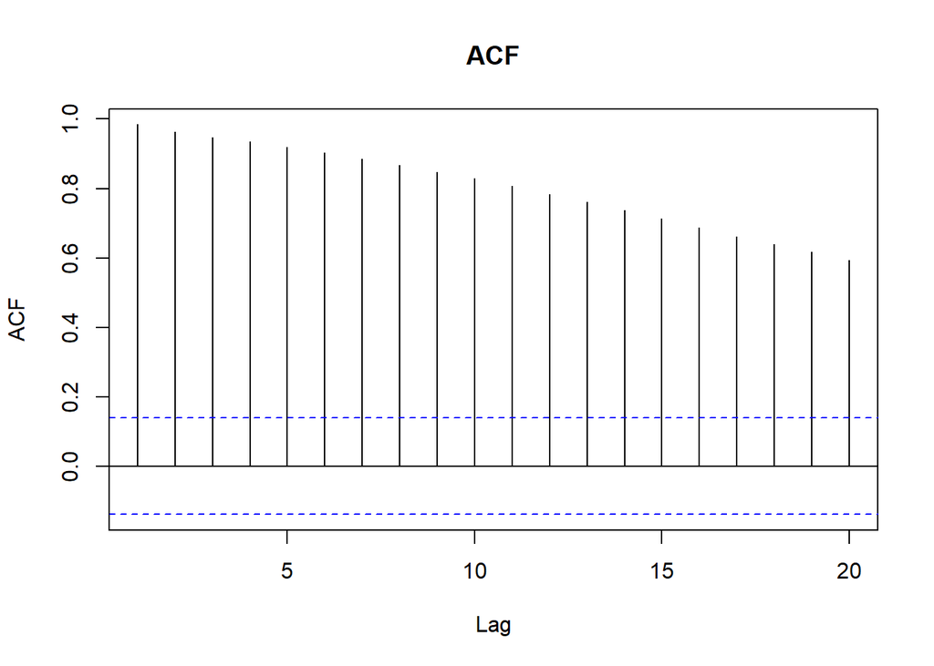

```r
#--CEK KESTASIONERAN---#
acf(dc.train, main="ACF", lag.max=20)
```

Berdasarkan plot ACF di atas, dapat dilihat bahwa plot *tails off slowly* yang menandakan data tidak stasioner dalam rataan

```r
adf.test(dc.train)
```

```
## Augmented Dickey-Fuller Test
## alternative: stationary
##
## Type 1: no drift no trend
##      lag   ADF p.value
## [1,]   0 -2.64  0.0100
## [2,]   1 -3.05  0.0100
## [3,]   2 -2.43  0.0168
## [4,]   3 -2.67  0.0100
## [5,]   4 -2.17  0.0307
## Type 2: with drift no trend
##      lag   ADF p.value
## [1,]   0 -1.71   0.441
## [2,]   1 -2.41   0.168
## [3,]   2 -1.41   0.553
## [4,]   3 -1.65   0.465
## [5,]   4 -1.59   0.489
## Type 3: with drift and trend
##      lag    ADF p.value
## [1,]   0 -1.223   0.901
## [2,]   1 -1.787   0.664
## [3,]   2 -0.985   0.938
## [4,]   3 -1.021   0.933
## [5,]   4 -1.369   0.840
## ----
## Note: in fact, p.value = 0.01 means p.value <= 0.01
```

```r
#stasioner
```

$H_0$ : Data tidak stasioner dalam rataan

$H_1$ : Data stasioner dalam rataan

Berdasarkan uji ADF tersebut, didapat *p-value* sebesar 0.840 yang lebih besar dari taraf nyata 5% sehingga terima $H_0$ dan menandakan bahwa data tidak stasioner dalam rataan. Hal ini sesuai dengan hasil eksplorasi menggunakan plot time series dan plot ACF.

#### Plot Box-Cox

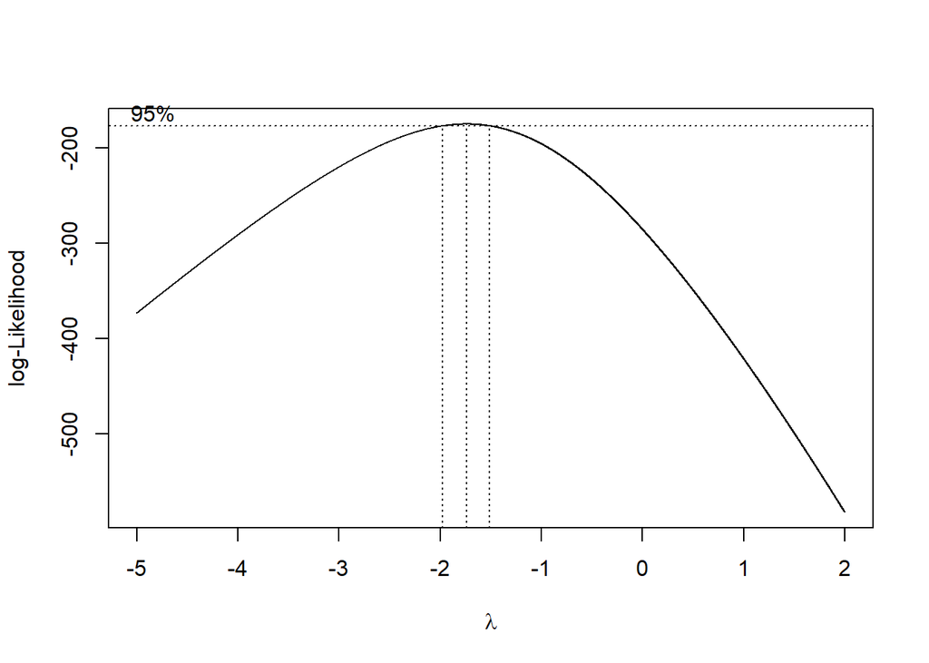

```r
index <- seq(1:249)
bc = boxcox(data~index, lambda = seq(-5,2,by=0.001))
```

```r
#Nilai Rounded Lambda
lambda <- bc$x[which.max(bc$y)]
lambda
```

```
## [1] -1.741
```

```r
#SK
bc$x[bc$y > max(bc$y) - 1/2 * qchisq(.95,1)]
```

```
##   [1] -1.977 -1.976 -1.975 -1.974 -1.973 -1.972 -1.971 -1.970 -1.969 -1.968
##  [11] -1.967 -1.966 -1.965 -1.964 -1.963 -1.962 -1.961 -1.960 -1.959 -1.958
##  [21] -1.957 -1.956 -1.955 -1.954 -1.953 -1.952 -1.951 -1.950 -1.949 -1.948
##  [31] -1.947 -1.946 -1.945 -1.944 -1.943 -1.942 -1.941 -1.940 -1.939 -1.938
##  [41] -1.937 -1.936 -1.935 -1.934 -1.933 -1.932 -1.931 -1.930 -1.929 -1.928
##  [51] -1.927 -1.926 -1.925 -1.924 -1.923 -1.922 -1.921 -1.920 -1.919 -1.918
##  [61] -1.917 -1.916 -1.915 -1.914 -1.913 -1.912 -1.911 -1.910 -1.909 -1.908
##  [71] -1.907 -1.906 -1.905 -1.904 -1.903 -1.902 -1.901 -1.900 -1.899 -1.898
##  [81] -1.897 -1.896 -1.895 -1.894 -1.893 -1.892 -1.891 -1.890 -1.889 -1.888
##  [91] -1.887 -1.886 -1.885 -1.884 -1.883 -1.882 -1.881 -1.880 -1.879 -1.878
## [101] -1.877 -1.876 -1.875 -1.874 -1.873 -1.872 -1.871 -1.870 -1.869 -1.868
## [111] -1.867 -1.866 -1.865 -1.864 -1.863 -1.862 -1.861 -1.860 -1.859 -1.858
## [121] -1.857 -1.856 -1.855 -1.854 -1.853 -1.852 -1.851 -1.850 -1.849 -1.848
## [131] -1.847 -1.846 -1.845 -1.844 -1.843 -1.842 -1.841 -1.840 -1.839 -1.838
## [141] -1.837 -1.836 -1.835 -1.834 -1.833 -1.832 -1.831 -1.830 -1.829 -1.828
```

[output cut: 32 more lines]

Gambar di atas menunjukkan nilai *rounded value* ($\lambda$) optimum sebesar **-1.741** dan pada selang kepercayaan 95% nilai memiliki batas bawah **-1.977** dan batas atas **-1.513**. Selang tersebut tidak memuat nilai satu sehingga dapat dikatakan bahwa data tidak stasioner dalam ragam.

### Penanganan Ketidakstasioneran Data

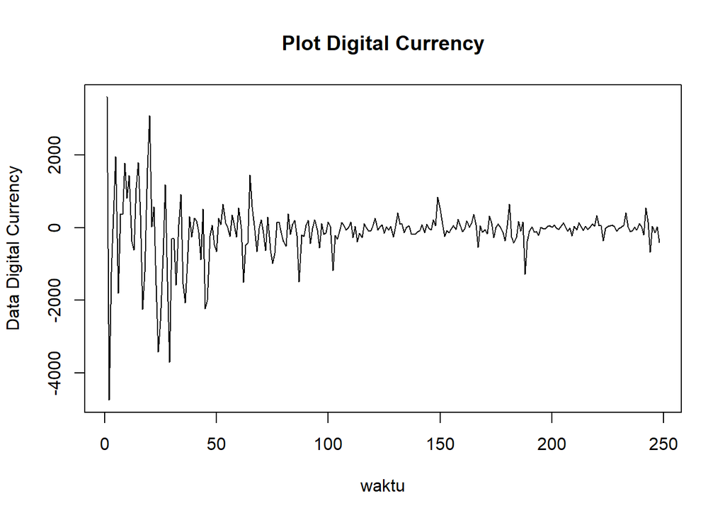

```r
train.diff<-diff(data,differences = 1)
plot.ts(train.diff, lty=1, xlab="waktu", ylab="Data Digital Currency", main="Plot Digital Currency")
```

Berdasarkan plot data deret waktu, terlihat bahwa data sudah stasioner dalam rataan ditandai dengan data bergerak pada nilai tengah tertentu (tidak terdapat trend ataupun musiman pada data)

### Identifikasi Model

#### Plot ACF

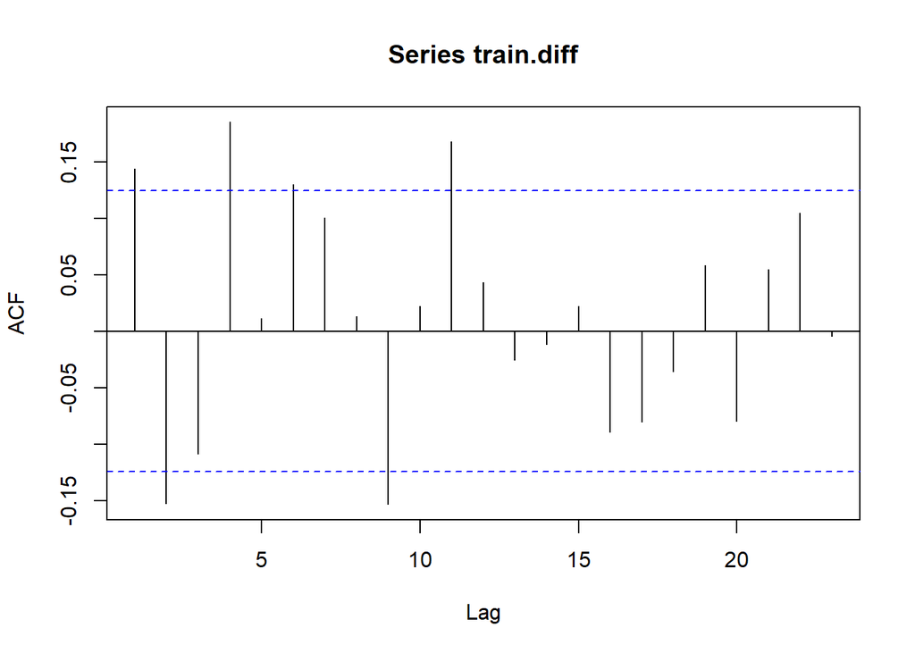

```r
acf(train.diff)
```

#### Plot PACF

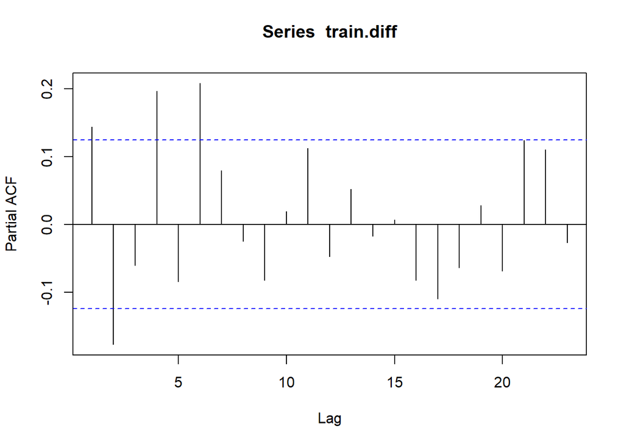

```r
pacf(train.diff)
```

#### Plot EACF

```r
eacf(train.diff)
```

```
## AR/MA
##   0 1 2 3 4 5 6 7 8 9 10 11 12 13
## 0 x x o x o x o o x o x  o  o  o
## 1 x x o x o o o o x o x  o  o  o
## 2 o x o o o o o o o o x  o  o  o
## 3 o x o x o o o o o o x  o  o  o
## 4 x x x x o o x o o o x  o  o  o
## 5 x x x x o x o o o o x  o  o  o
## 6 o o x x o o o o o o x  o  o  o
## 7 x o x x o o x o o o x  o  o  o
```

### Pendugaan Parameter Model Tentatif

#### ARIMA(0,1,1)

```r
model1.da=Arima(train.diff, order=c(0,1,1),method="ML")
summary(model1.da) #AIC=4753.18
```

```
## Series: train.diff
## ARIMA(0,1,1)
##
## Coefficients:
##           ma1
##       -0.9837
## s.e.   0.0152
##
## sigma^2 = 630806:  log likelihood = -2001
## AIC=4006.01   AICc=4006.06   BIC=4013.03
##
## Training set error measures:
##                    ME     RMSE      MAE       MPE     MAPE      MASE      ACF1
## Training set 3.801455 791.0239 420.8501 -7.017296 410.6857 0.7632593 0.2401042
```

```r
lmtest::coeftest(model1.da) #seluruh parameter signifikan
```

```
##
## z test of coefficients:
##
##     Estimate Std. Error z value  Pr(>|z|)
## ma1 -0.98368    0.01522 -64.631 < 2.2e-16 ***
## ---
## Signif. codes:  0 '***' 0.001 '**' 0.01 '*' 0.05 '.' 0.1 ' ' 1
```

#### ARIMA(1,1,0)

```r
model2.da=Arima(train.diff, order=c(1,1,0),method="ML")
summary(model2.da) #AIC=4917.41
```

```
## Series: train.diff
## ARIMA(1,1,0)
##
## Coefficients:
##           ar1
##       -0.3049
## s.e.   0.0721
##
## sigma^2 = 950288:  log likelihood = -2049.94
## AIC=4103.89   AICc=4103.94   BIC=4110.91
##
## Training set error measures:
##                     ME     RMSE      MAE      MPE     MAPE      MASE
## Training set -18.90906 970.8884 528.2174 185.9219 439.1487 0.9579819
##                     ACF1
## Training set -0.01702443
```

```r
lmtest::coeftest(model2.da) #seluruh parameter signifikan
```

```
##
## z test of coefficients:
##
##      Estimate Std. Error z value  Pr(>|z|)
## ar1 -0.304871   0.072094 -4.2288 2.349e-05 ***
## ---
## Signif. codes:  0 '***' 0.001 '**' 0.01 '*' 0.05 '.' 0.1 ' ' 1
```

#### ARIMA(1,1,1)

```r
model3.da=Arima(train.diff, order=c(1,1,1),method="ML")
summary(model3.da) #AIC=4761.39
```

```
## Series: train.diff
## ARIMA(1,1,1)
##
## Coefficients:
##          ar1      ma1
##       0.1552  -0.9899
## s.e.  0.0675   0.0146
##
## sigma^2 = 619657:  log likelihood = -1998.38
## AIC=4002.76   AICc=4002.86   BIC=4013.29
##
## Training set error measures:
##                   ME     RMSE      MAE      MPE     MAPE      MASE      ACF1
## Training set 1.84484 782.4072 412.5912 37.29808 382.7409 0.7482807 0.1308085
```

```r
lmtest::coeftest(model3.da) #seluruh parameter signifikan
```

```
##
## z test of coefficients:
##
##      Estimate Std. Error  z value Pr(>|z|)
## ar1  0.155177   0.067519   2.2983  0.02155 *
## ma1 -0.989926   0.014609 -67.7597  < 2e-16 ***
## ---
## Signif. codes:  0 '***' 0.001 '**' 0.01 '*' 0.05 '.' 0.1 ' ' 1
```

#### ARIMA(0,1,2)

```r
model4.da=Arima(train.diff, order=c(0,1,2),method="ML")
summary(model4.da) #AIC=4748.3
```

```
## Series: train.diff
## ARIMA(0,1,2)
##
## Coefficients:
##           ma1     ma2
##       -0.7546  -0.235
## s.e.   0.0741   0.075
##
## sigma^2 = 611555:  log likelihood = -1996.81
## AIC=3999.63   AICc=3999.73   BIC=4010.16
##
## Training set error measures:
##                     ME     RMSE      MAE      MPE     MAPE      MASE       ACF1
## Training set -1.923499 777.2753 411.3867 37.11407 386.8097 0.7460962 0.06199287
```

```r
lmtest::coeftest(model4.da) #seluruh parameter signifikan
```

```
##
## z test of coefficients:
##
##      Estimate Std. Error  z value  Pr(>|z|)
## ma1 -0.754643   0.074091 -10.1854 < 2.2e-16 ***
## ma2 -0.234989   0.075024  -3.1322  0.001735 **
## ---
## Signif. codes:  0 '***' 0.001 '**' 0.01 '*' 0.05 '.' 0.1 ' ' 1
```

#### ARIMA(1,1,2)

```r
model5.da=Arima(train.diff, order=c(1,1,2),method="ML")
summary(model5.da) #AIC=4749.85
```

```
## Series: train.diff
## ARIMA(1,1,2)
##
## Coefficients:
##           ar1      ma1      ma2
##       -0.1466  -0.6262  -0.3604
## s.e.   0.1567   0.1416   0.1387
##
## sigma^2 = 612044:  log likelihood = -1996.37
## AIC=4000.74   AICc=4000.91   BIC=4014.78
##
## Training set error measures:
##                     ME     RMSE      MAE      MPE     MAPE      MASE      ACF1
## Training set -2.185311 775.9978 411.5141 23.00298 398.4081 0.7463273 0.0699526
```

```r
lmtest::coeftest(model5.da) #terdapat parameter tidak signifikan
```

```
##
## z test of coefficients:
##
##     Estimate Std. Error z value  Pr(>|z|)
## ar1 -0.14659    0.15671 -0.9354  0.349592
## ma1 -0.62620    0.14157 -4.4231 9.729e-06 ***
## ma2 -0.36041    0.13868 -2.5989  0.009351 **
## ---
## Signif. codes:  0 '***' 0.001 '**' 0.01 '*' 0.05 '.' 0.1 ' ' 1
```

#### ARIMA(2,1,2)

```r
model6.da=Arima(train.diff, order=c(2,1,2),method="ML")
summary(model6.da) #AIC=4749.52
```

```
## Series: train.diff
## ARIMA(2,1,2)
##
## Coefficients:
##          ar1      ar2      ma1     ma2
##       0.3567  -0.3705  -1.0912  0.1774
## s.e.  0.1699   0.0880   0.1684  0.1743
##
## sigma^2 = 591075:  log likelihood = -1990.85
## AIC=3991.7   AICc=3991.95   BIC=4009.25
##
## Training set error measures:
##                    ME     RMSE      MAE       MPE     MAPE      MASE       ACF1
## Training set -25.7295 761.0242 417.0881 -140.0648 533.3759 0.7564363 0.02615341
```

```r
lmtest::coeftest(model6.da) #terdapat parameter tidak signifikan
```

```
##
## z test of coefficients:
##
##      Estimate Std. Error z value  Pr(>|z|)
## ar1  0.356718   0.169883  2.0998   0.03575 *
## ar2 -0.370540   0.088047 -4.2084 2.571e-05 ***
## ma1 -1.091210   0.168416 -6.4793 9.217e-11 ***
## ma2  0.177390   0.174344  1.0175   0.30893
## ---
## Signif. codes:  0 '***' 0.001 '**' 0.01 '*' 0.05 '.' 0.1 ' ' 1
```

Berdasarkan pendugaan parameter di atas, nilai AIC terkecil dimiliki oleh model ARIMA(2,1,2) tetapi parameter model ARIMA(2,1,2) tidak seluruhnya signifikan. Selanjutnya nilai AIC terkecil kedua dimiliki oleh model ARIMA(0,1,2) dan parameter model ARIMA(0,1,2) juga seluruhnya signifikan sehingga model yang dipilih adalah model ARIMA(0,1,2).

### Analisis Sisaan

Model terbaik hasil identifikasi kemudian dicek asumsi sisaannya. Sisaan model ARIMA harus memenuhi asumsi normalitas, kebebasan sisaan, dan kehomogenan ragam. Diagnostik model dilakukan secara eksplorasi dan uji formal.

#### Eksplorasi Sisaan

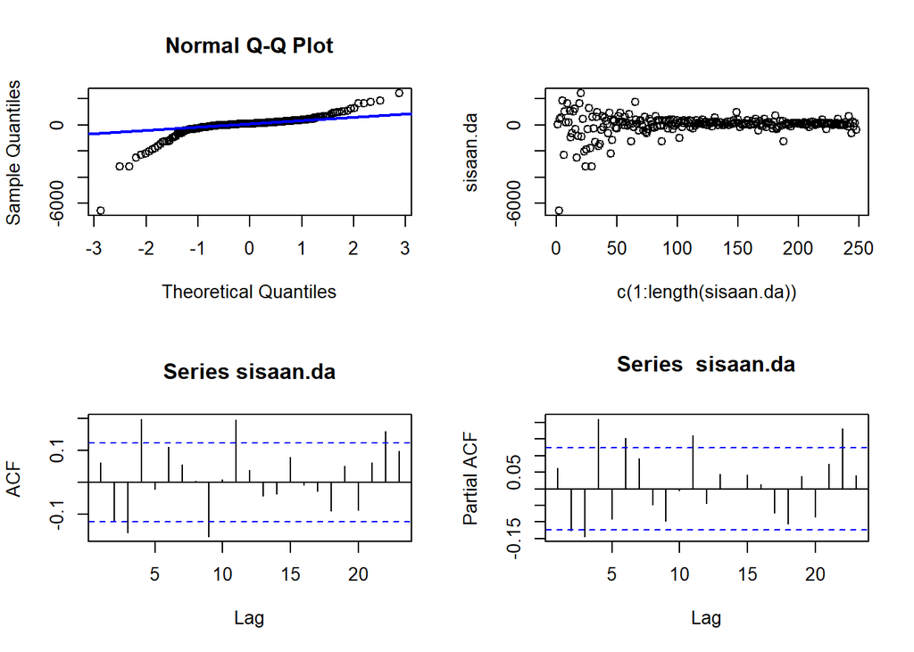

```r
#Eksplorasi
sisaan.da <- model4.da$residuals
par(mfrow=c(2,2))
qqnorm(sisaan.da)
qqline(sisaan.da, col = "blue", lwd = 2)
plot(c(1:length(sisaan.da)),sisaan.da)
acf(sisaan.da)
pacf(sisaan.da)
```

```r
par(mfrow = c(1,1))
```

#### Uji Formal

```r
#1) Sisaan Menyebar Normal
ks.test(sisaan.da,"pnorm")  #tak tolak H0 > sisaan menyebar normal
```

```
##
##  Asymptotic one-sample Kolmogorov-Smirnov test
##
## data:  sisaan.da
## D = 0.65307, p-value < 2.2e-16
## alternative hypothesis: two-sided
```

Selain dengan eksplorasi, asumsi tersebut dapat diuji menggunakan uji formal. Pada tahapan ini uji formal yang digunakan untuk normalitas adalah uji Kolmogorov-Smirnov (KS). Hipotesis pada uji KS adalah sebagai berikut.

$H_0$ : Sisaan menyebar normal

$H_1$ : Sisaan tidak menyebar normal

Berdasarkan uji KS tersebut, didapat *p-value* sebesar 0.00 yang kurang dari taraf nyata 5% sehingga tolak $H_0$ dan menandakan bahwa sisaan tidak menyebar normal. Hal ini sesuai dengan hasil eksplorasi menggunakan plot kuantil-kuantil normal.

```r
#2) Sisaan saling bebas/tidak ada autokorelasi
Box.test(sisaan.da, type = "Ljung")  #tak tolak H0 > sisaan saling bebas
```

```
##
##  Box-Ljung test
##
## data:  sisaan.da
## X-squared = 0.96467, df = 1, p-value = 0.326
```

Selanjutnya akan dilakukan uji formal untuk kebebasan sisaan menggunakan uji Ljung-Box. Hipotesis yang digunakan adalah sebagai berikut.

$H_0$ : Sisaan saling bebas

$H_1$ : Sisaan tidak tidak saling bebas

```r
#3) Sisaan homogen
Box.test((sisaan.da)^2, type = "Ljung")  #tak tolak H0 > sisaan homogen
```

```
##
##  Box-Ljung test
##
## data:  (sisaan.da)^2
## X-squared = 0.71298, df = 1, p-value = 0.3985
```

Hipotesis yang digunakan untuk uji kehomogenan ragam adalah sebagai berikut.

$H_0$ : Ragam sisaan homogen

$H_1$ : Ragam sisaan tidak homogen

```r
#4) Nilai tengah sisaan sama dengan nol
t.test(sisaan.da, mu = 0, conf.level = 0.95)  #tak tolak h0 > nilai tengah sisaan sama dengan 0
```

```
##
##  One Sample t-test
##
## data:  sisaan.da
## t = -0.038893, df = 247, p-value = 0.969
## alternative hypothesis: true mean is not equal to 0
## 95 percent confidence interval:
##  -99.33412  95.48712
## sample estimates:
## mean of x
## -1.923499
```

Terakhir, dengan uji-t, akan dicek apakah nilai tengah sisaan sama dengan nol. Hipotesis yang diujikan sebagai berikut.

$H_0$ : nilai tengah sisaan sama dengan 0

$H_1$ : nilai tengah sisaan tidak sama dengan 0

Berdasarkan uji-ttersebut, didapat *p-value* sebesar 0.969 yang lebih besar dari taraf nyata 5% sehingga tak tolak $H_0$ dan menandakan bahwa nilai tengah sisaan sama dengan nol. Hal ini berbeda dengan eksplorasi.

### Peramalan

```r
#---FORECAST---#
ramalan.da <- forecast::forecast(model4.da, h = length(dc.test))
ramalan.da
```

```
##     Point Forecast     Lo 80    Hi 80     Lo 95    Hi 95
## 249     -152.71445 -1155.043 849.6138 -1685.643 1380.214
## 250      -67.10404 -1099.221 965.0126 -1645.590 1511.382
## 251      -67.10404 -1099.273 965.0649 -1645.670 1511.462
## 252      -67.10404 -1099.325 965.1172 -1645.750 1511.542
## 253      -67.10404 -1099.378 965.1695 -1645.830 1511.622
## 254      -67.10404 -1099.430 965.2218 -1645.910 1511.702
## 255      -67.10404 -1099.482 965.2741 -1645.990 1511.782
## 256      -67.10404 -1099.534 965.3264 -1646.070 1511.862
## 257      -67.10404 -1099.587 965.3787 -1646.150 1511.942
## 258      -67.10404 -1099.639 965.4309 -1646.230 1512.022
## 259      -67.10404 -1099.691 965.4832 -1646.310 1512.102
## 260      -67.10404 -1099.744 965.5355 -1646.390 1512.182
## 261      -67.10404 -1099.796 965.5878 -1646.470 1512.262
## 262      -67.10404 -1099.848 965.6401 -1646.550 1512.342
```

[output cut: 35 more lines]

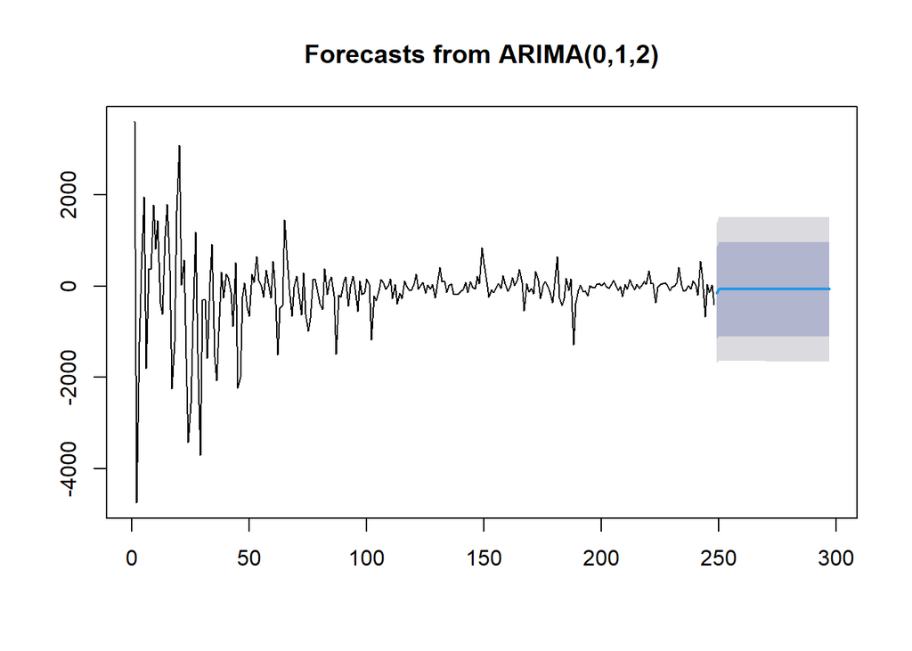

```r
data.ramalan.da <- ramalan.da$mean
plot(ramalan.da)
```

```r
pt_1 <- data[200] #nilai akhir data latih
hasil.forc.Diff <- data.ramalan.da
hasil <- diffinv(hasil.forc.Diff, differences = 1) + pt_1
hasil
```

```
## Time Series:
## Start = 248
## End = 297
## Frequency = 1
##  [1] 9276.490 9123.776 9056.672 8989.567 8922.463 8855.359 8788.255 8721.151
##  [9] 8654.047 8586.943 8519.839 8452.735 8385.631 8318.527 8251.423 8184.319
## [17] 8117.215 8050.111 7983.007 7915.903 7848.799 7781.695 7714.591 7647.487
## [25] 7580.383 7513.279 7446.175 7379.071 7311.967 7244.862 7177.758 7110.654
## [33] 7043.550 6976.446 6909.342 6842.238 6775.134 6708.030 6640.926 6573.822
## [41] 6506.718 6439.614 6372.510 6305.406 6238.302 6171.198 6104.094 6036.990
## [49] 5969.886 5902.782
```

```r
#has.1 sama hasilnya dengan: cumsum(c(pt_1,hasil.forc.Diff))
```

```r
perbandingan.da<-matrix(data=c(head(dc.test, n=30), hasil[-1]),
                     nrow = 30, ncol = 2)
colnames(perbandingan.da)<-c("Aktual","Hasil Forecast")
perbandingan.da
```

```
##        Aktual Hasil Forecast
##  [1,] 9279.54       9123.776
##  [2,] 9343.82       9056.672
##  [3,] 9345.00       8989.567
##  [4,] 9299.28       8922.463
##  [5,] 9317.48       8855.359
##  [6,] 9440.79       8788.255
##  [7,] 9470.00       8721.151
##  [8,] 9379.42       8654.047
##  [9,] 9375.00       8586.943
## [10,] 9145.24       8519.839
## [11,] 9190.00       8452.735
## [12,] 9125.00       8385.631
## [13,] 9261.96       8318.527
## [14,] 9292.00       8251.423
```

[output cut: 16 more lines]

```r
accuracy(ts(hasil[-1]), head(dc.test, n=30))
```

```
##                ME     RMSE      MAE      MPE     MAPE
## Test set 1225.769 1400.125 1225.769 12.99395 12.99395
```